# Análisis Avanzado de Datos - Proyecto Final

**Felipe Sarmiento, Juan S. Henao, Wilson**

# Regularización Ridge y LASSO en Regresión logística multinomial

La regresión logística multinomial es un tipo de regresión logística que trata problemas de clasificación multiclase, en los que la variable objetivo puede tener tres o más resultados posibles.

## Regresión logística multinomial

En una regresión logística binaria, utilizamos la función logística para modelar la probabilidad de una respuesta binaria basada en una o más variables predictoras (o independientes). Sin embargo, cuando nuestra variable de respuesta tiene más de dos categorías, necesitamos un método diferente. Aquí es donde entra en juego la Regresión Logística Multinomial.

El método se utiliza para explicar la relación entre una variable dependiente nominal y una o más variables independientes. La variable nominal tiene más de dos niveles, lo que significa que puede tener más de dos resultados posibles.

Profundicemos un poco en la teoría antes de empezar. Nuestro modelo tiene $K$ resultados posibles. Los denominaremos $G={1,2,...,K}$. El objetivo de nuestro modelo es predecir la probabilidad de que una observación dada cae en una categoría particular, dadas sus características de entrada $X$. Matemáticamente, representamos esto como $Pr(G=k|X=x)$.

$Pr(G=k|X=x) = \frac{e^{\beta_{0k}+\beta_{k}^T x}}{\sum_{\ell=1}^{K} e^{\beta_{0\ell}+\beta_{\ell}^T x}}$

Utilizamos un predictor lineal para cada clase, y las probabilidades suman $1$ en todas las clases.

En esta ecuación:

- $\beta_{0k}$ es el intercepto para la clase $k$.
- $\beta_{k}$ es el vector de coeficientes para la clase $k$.
- $X$ representa las variables predictoras.

### La librería Glmnet

Glmnet es un paquete que ajusta un modelo lineal generalizado mediante máxima verosimilitud penalizada. La ruta de regularización se calcula para la penalización lasso o elasticnet en una grid de valores para el parámetro de regularización lambda. Se ajusta a modelos de regresión lineal, logística y multinomial, poisson y Cox. Los modelos ajustados permiten realizar diversas predicciones.

La regularización es una técnica que limita el valor de los coeficientes estimados incluso pudiendo penalizar algunos de ellos hasta cero, lo que ayuda a interpretar el modelo final. De este modo, el modelo realiza automáticamente la selección de variables. Se utiliza un parámetro para controlar la cantidad de regularización y se elige el mejor parámetro de ajuste que equilibre el ajuste insuficiente y el ajuste excesivo.

En el caso de los datos MNIST, se selecciona una familia multinomial en la que la respuesta son los dígitos 0-9.

## El dataset MNIST

El conjunto de datos MNIST (Modified National Institute of Standards and Technology) es una gran colección de dígitos manuscritos que se utilizan habitualmente para entrenar diversos sistemas de procesamiento de imágenes. El conjunto de datos contiene 60.000 imágenes de entrenamiento y 10.000 imágenes de prueba. Cada imagen del conjunto de datos es una imagen en escala de grises de 28x28 píxeles, que representa un dígito entre 0 y 9.

El reconocimiento de dígitos manuscritos es un problema canónico en el campo del procesamiento de imágenes y el aprendizaje automático. Las variaciones en la escritura manuscrita de los distintos individuos plantean un reto complejo, lo que lo convierte en un ejemplo excelente para enseñar y comprender algoritmos avanzados de aprendizaje automático.

En el contexto de la regresión logística multinomial, el conjunto de datos MNIST es especialmente relevante por un par de razones:

- **Problema multiclase:** Dado que hay 10 dígitos (de 0 a 9), se trata de un problema de clasificación multiclase, y la regresión logística multinomial es un ajuste natural para este tipo de tareas.
- **Alta dimensionalidad:** Como cada imagen tiene 28x28 = 784 píxeles como características, el problema es de alta dimensionalidad. Cuando el número de características es grande en relación con el número de observaciones, el modelo logit adolece de problemas como la separación completa, las estimaciones de los parámetros no están bien definidas (algunas son infinitas) y/o el máximo de log-verosimilitud se alcanza en 0. El conjunto de datos MNIST ofrece una excelente oportunidad para aplicar e ilustrar técnicas de regularización como Lasso y Ridge, y para mostrar sus efectos sobre el rendimiento del modelo.
  - **Separación completa:** Se trata de una situación en la que los predictores predicen perfectamente el resultado. En otras palabras, se puede trazar un límite que separe completamente las clases de los datos. La separación completa es un problema porque hace que las estimaciones de los parámetros del modelo de regresión logística vayan a infinito, lo que hace que carezcan de sentido.
  - **No unicidad de las estimaciones:** En entornos de alta dimensión, normalmente hay muchas combinaciones de predictores que pueden predecir el resultado igual de bien. Esto significa que no hay un único conjunto de valores de parámetros que maximice la función de verosimilitud (la función matemática que cuantifica lo bien que el modelo se ajusta a los datos). Una vez más, esto hace que los valores estimados de los parámetros sean ininterpretables.
  - **Máxima verosimilitud logarítmica en cero:** En algunos casos, cuando se trata de datos de alta dimensión, el modelo de regresión logística puede alcanzar la máxima verosimilitud logarítmica en cero. Esto implica que el modelo no se basa en los predictores para hacer predicciones y, en su lugar, basa sus predicciones en la clase más frecuente en los datos.

```r
# Cargar librerias
library(glmnet)
library(keras)

# Cargar el dataset MNIST
mnist <- dataset_mnist()

# Preprocesar los datos
x_train <- mnist$train$x
y_train <- mnist$train$y
x_test <- mnist$test$x
y_test <- mnist$test$y
```

```r
# Convertir las imagenes en matrices y normalizar
x_train <- array_reshape(x_train, c(nrow(x_train), 784))
x_test <- array_reshape(x_test, c(nrow(x_test), 784))
x_train <- x_train / 255
x_test <- x_test / 255
```

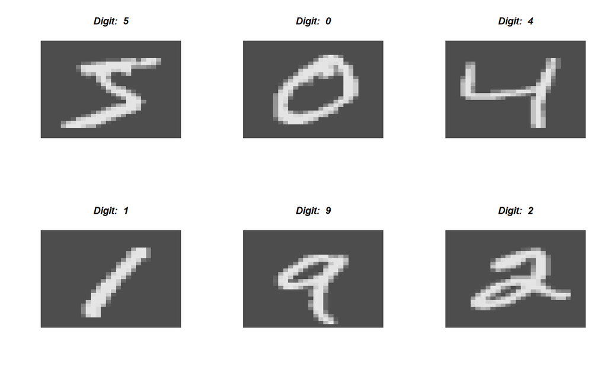

```r
# Function to visualize a digit
show_digit <- function(vec, digit_title) {
  image(matrix(as.numeric(vec), nrow = 28)[,28:1], axes = FALSE, col = grey.colors(256))
  title(main = digit_title, col.main ="black", font.main = 4)
}

#Area de gráfico
par(mfrow=c(2,3))

# Mostrar ejemplos de los digitos
show_digit(x_train[1,], paste("Digit: ", y_train[1]))
show_digit(x_train[2,], paste("Digit: ", y_train[2]))
show_digit(x_train[3,], paste("Digit: ", y_train[3]))
show_digit(x_train[4,], paste("Digit: ", y_train[4]))
show_digit(x_train[5,], paste("Digit: ", y_train[5]))
show_digit(x_train[6,], paste("Digit: ", y_train[6]))
```

## Modelo multinomial sin regularización

```r
# Cargar librerias
library(nnet)

# Ajustar el modelo
model <- multinom(y_train ~ ., data = data.frame(x_train, y_train = as.factor(y_train)), MaxNWts = 10000)
```

### Evaluación del desempeño del mmodelo sin regularización

```r
# Predecir en el set de datos de prueba
predictions <- predict(model, newdata = data.frame(x_test))

# CConvertir a númerico
predictions <- as.numeric(predictions)

# Cálculo de la presición
accuracy <- mean(predictions == y_test)
print(paste("Presición: ", accuracy))
```

```
## [1] "Presición:  0.0084"
```

```r
# Confusion matrix
library(caret)
library(yardstick)
```

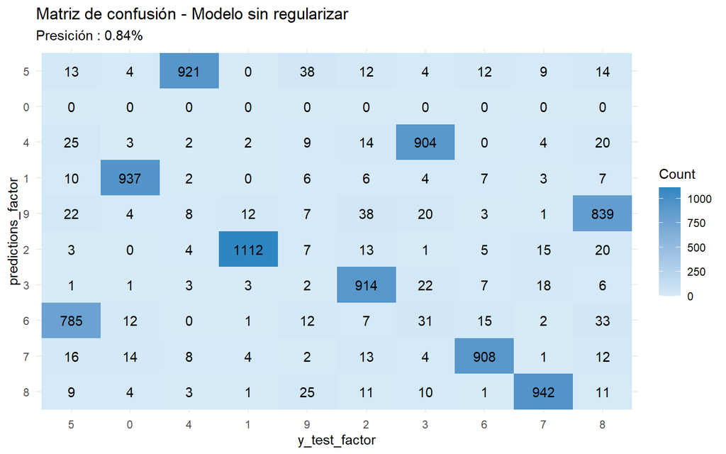

```r
library(ggplot2)

# Ensure factor levels match in predictions and actual labels
predictions_factor <- factor(predictions, levels = unique(y_train))
y_test_factor <- factor(y_test, levels = unique(y_train))

# Convert confusion matrix to table
cm <- conf_mat(table(predictions_factor, y_test_factor))


# Plot heatmap with theme minimal and plasma colors
autoplot(cm, type = "heatmap") +
  scale_fill_gradient(low="#D6EAF8",high = "#2E86C1") +
  theme_minimal() +
  labs(title = "Matriz de confusión - Modelo sin regularizar",
       subtitle = "Presición : 0.84%",
       fill = "Count") +
  theme(legend.position = "right")
```

## 4. Regularized Multinomial Logistic Regression

La penalización de la red elástica minimiza la función de probabilidad logarítmica negativa:

$[ \ell(\beta_{0k},\beta_{k}) = -[ \frac{1}{N} \sum_{i=1}^{N} ( \sum_{k=1}^{K} y_{il} (\beta_{0k}+x_{i}^{T} \beta_{k}) - \log(\sum_{\ell=1}^{K}e^{\beta_{0\ell}+x_{i}^{T} \beta_{\ell}}))]$ + $\lambda[(1-\alpha) \frac{\| \beta \|_{F}^{2}}{2} + \alpha \sum_{j=1}^{p} \| \beta_{j} \|_{q}]$

En esta ecuación,

- $N$ es el número de observaciones.
- $y_{il}$es una variable indicadora igual a 1 si la observación $i$ pertenece a la clase$l$ y a 0 en caso contrario.
- $\lambda$ es el parámetro de regularización. Controla el equilibrio entre la log-verosimilitud y el término de penalización.
- $\alpha$ es el parámetro de mezcla que determina el peso relativo de las penalizaciones de lazo (L_1) y de Ridge (L_2).
- $\beta$ es una matriz $p×K$ de coeficientes.

La regularización añade un término de penalización a la función de coste que optimiza el modelo. Este término de penalización fomenta coeficientes más pequeños o dispersos, dependiendo del tipo de regularización utilizada:

- Lasso ($L_1$ regularización) fomenta la dispersión al permitir que algunos coeficientes sean exactamente cero. De este modo, se selecciona un modelo más sencillo con menos predictores, lo que facilita la interpretación.
- La regularización Ridge ($L_2$) desalienta los coeficientes grandes penalizando el cuadrado de su tamaño, pero no suele dar lugar a coeficientes cero. Puede ser útil cuando se tienen predictores correlacionados.
- La eslatic-net es una combinación de regularización lasso y ridge. Puede ser eficaz cuando hay múltiples características correlacionadas.

```r
# Load the necessary package
library(glmnet)

#Subconjunto de las prímeras 1000 obervaciones
train1 <- x_train[1:1000,]

# Convertir los labels a factores
Y <- as.factor(y_train[1:1000])
```

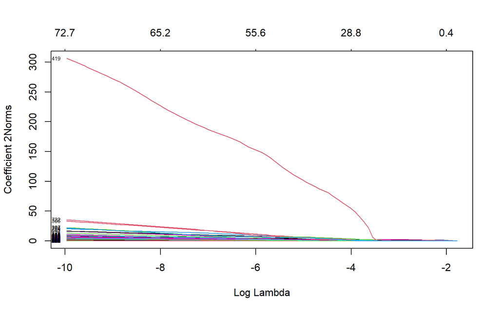

```r
fit_ungrouped <- glmnet(train1, Y, family = "multinomial", type.multinomial = "ungrouped", alpha=1)
# Plot the model
plot(fit_ungrouped, xvar = "lambda", label = TRUE, type.coef = "2norm")
```

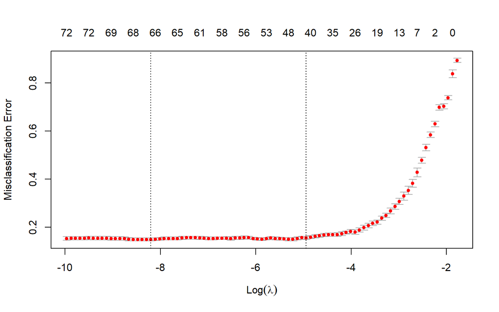

```r
#Cross validation
fit <- cv.glmnet(train1, Y, family = "multinomial", type.multinomial = "ungrouped", alpha=1, type.measure = "class")
plot(fit)
```

```r
# Extract the lambda that minimizes the cross-validated error
lambda_best <- fit$lambda.min
print(lambda_best)
```

```
## [1] 0.000274831
```

```r
# Using lambda.min for regularized model
coef.apprx <- coef(fit, s = lambda_best, exact = FALSE)
```

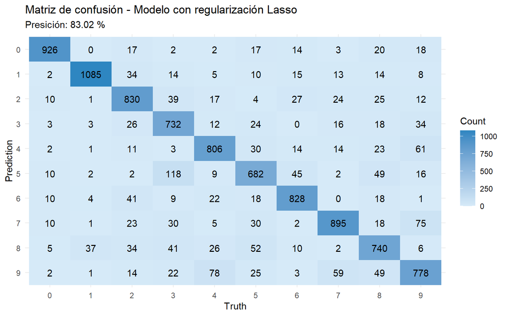

```r
# Confusion matrix
library(caret)
library(yardstick)
library(ggplot2)
library(ggfortify)
# Predict using the best lambda
lasso_predictions_best <- predict(fit_ungrouped, s = lambda_best, newx = x_test, type = "class")

# Convert the predictions and actual values to factors
y_test_factor <- as.factor(y_test)
lasso_predictions_best_factor <- as.factor(lasso_predictions_best)

# Convert predictions to numeric
predictions <- as.numeric(lasso_predictions_best_factor)

# Evaluate the model
accuracy <- mean(lasso_predictions_best_factor == y_test)
# Create the confusion matrix using yardstick's conf_mat function
conf_mat <- yardstick::conf_mat(data = data.frame(Reference = y_test_factor, Prediction = lasso_predictions_best_factor),
                                truth = Reference,
                                estimate = Prediction)

# Plot heatmap with theme minimal and plasma colors
autoplot(conf_mat, type = "heatmap") +
  scale_fill_gradient(low="#D6EAF8",high = "#2E86C1") +
  theme_minimal() +
  labs(title = "Matriz de confusión - Modelo con regularización Lasso",
       subtitle = paste("Presición:", accuracy*100,"%"),
       fill = "Count") +
  theme(legend.position = "right")
```

## 4. Regularized Multinomial Logistic Regression

```r
# Subset the first 1000 observations
train1 <- x_train[1:1000,]
# Convert label into a factor
Y <- as.factor(y_train[1:1000])

# Fit the multinomial lasso model using 10-fold cross-validation, alpha =0 para Ridge
fit_ridge <- cv.glmnet(train1, Y, family = "multinomial", type.multinomial = "ungrouped", alpha=0, type.measure = "class")
# Extract the lambda that minimizes the cross-validated error
lambda_best_ridge <- fit_ridge$lambda.min

# Predict using the best lambda
ridge_predictions_best <- predict(fit_ridge, s = lambda_best_ridge, newx = x_test, type = "class")

# Convert the predictions and actual values to factors
y_test_factor <- as.factor(y_test)
ridge_predictions_best_factor <- as.factor(ridge_predictions_best)

# Convert predictions to numeric
predictions <- as.numeric(ridge_predictions_best_factor)

# Evaluate the model
accuracy <- mean(ridge_predictions_best_factor == y_test)
print(paste("Accuracy: ", accuracy))
```

```
## [1] "Accuracy:  0.8627"
```

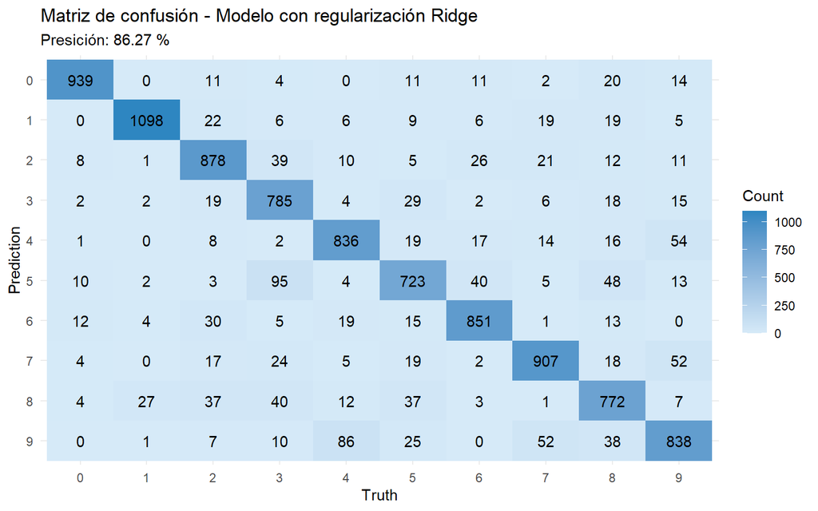

```r
# Create the confusion matrix using yardstick's conf_mat function
conf_mat <- yardstick::conf_mat(data = data.frame(Reference = y_test_factor, Prediction = ridge_predictions_best_factor),
                                truth = Reference,
                                estimate = Prediction)

# Plot heatmap with theme minimal and plasma colors
autoplot(conf_mat, type = "heatmap") +
  scale_fill_gradient(low="#D6EAF8",high = "#2E86C1") +
  theme_minimal() +
  labs(title = "Matriz de confusión - Modelo con regularización Ridge",
       subtitle = paste("Presición:", accuracy*100,"%"),
       fill = "Count") +
  theme(legend.position = "right")
```